# Risk Factor Analysis

## Outcome Variable

**Outcome Variable:** ever_wasted

## Predictor Variables

**Intervention Variable:** mbmi

**Adjustment Set:**

- arm
- W_mage
- meducyrs
- feducyrs
- hhwealth_quart
- W_nchldlt5
- brthmon
- W_parity
- delta_W_mage
- delta_meducyrs
- delta_feducyrs
- delta_hhwealth_quart
- delta_W_nchldlt5
- delta_brthmon
- delta_W_parity

## Stratifying Variables

The analysis was stratified on these variable(s):

- agecat
- studyid
- country

## Data Summary

| agecat | studyid | country | mbmi | ever_wasted | n_cell | n |
| --- | --- | --- | --- | --- | --- | --- |
| 0-24 months | iLiNS-Zinc | BURKINA FASO | Normal weight | 0 | 2161 | 3217 |
| 0-24 months | iLiNS-Zinc | BURKINA FASO | Normal weight | 1 | 602 | 3217 |
| 0-24 months | iLiNS-Zinc | BURKINA FASO | Underweight | 0 | 323 | 3217 |
| 0-24 months | iLiNS-Zinc | BURKINA FASO | Underweight | 1 | 131 | 3217 |
| 0-24 months | JiVitA-3 | BANGLADESH | Normal weight | 0 | 12433 | 26836 |
| 0-24 months | JiVitA-3 | BANGLADESH | Normal weight | 1 | 4127 | 26836 |
| 0-24 months | JiVitA-3 | BANGLADESH | Underweight | 0 | 7478 | 26836 |
| 0-24 months | JiVitA-3 | BANGLADESH | Underweight | 1 | 2798 | 26836 |
| 0-24 months | LCNI-5 | MALAWI | Normal weight | 0 | 651 | 837 |
| 0-24 months | LCNI-5 | MALAWI | Normal weight | 1 | 41 | 837 |
| 0-24 months | LCNI-5 | MALAWI | Underweight | 0 | 120 | 837 |
| 0-24 months | LCNI-5 | MALAWI | Underweight | 1 | 25 | 837 |
| 0-24 months | MAL-ED | BANGLADESH | Normal weight | 0 | 154 | 254 |
| 0-24 months | MAL-ED | BANGLADESH | Normal weight | 1 | 68 | 254 |
| 0-24 months | MAL-ED | BANGLADESH | Underweight | 0 | 15 | 254 |
| 0-24 months | MAL-ED | BANGLADESH | Underweight | 1 | 17 | 254 |
| 0-24 months | MAL-ED | BRAZIL | Normal weight | 0 | 194 | 221 |
| 0-24 months | MAL-ED | BRAZIL | Normal weight | 1 | 17 | 221 |
| 0-24 months | MAL-ED | BRAZIL | Underweight | 0 | 8 | 221 |
| 0-24 months | MAL-ED | BRAZIL | Underweight | 1 | 2 | 221 |
| 0-24 months | MAL-ED | INDIA | Normal weight | 0 | 105 | 242 |
| 0-24 months | MAL-ED | INDIA | Normal weight | 1 | 88 | 242 |
| 0-24 months | MAL-ED | INDIA | Underweight | 0 | 20 | 242 |
| 0-24 months | MAL-ED | INDIA | Underweight | 1 | 29 | 242 |
| 0-24 months | MAL-ED | NEPAL | Normal weight | 0 | 164 | 238 |
| 0-24 months | MAL-ED | NEPAL | Normal weight | 1 | 74 | 238 |
| 0-24 months | MAL-ED | NEPAL | Underweight | 0 | 0 | 238 |
| 0-24 months | MAL-ED | NEPAL | Underweight | 1 | 0 | 238 |
| 0-24 months | MAL-ED | PERU | Normal weight | 0 | 260 | 290 |
| 0-24 months | MAL-ED | PERU | Normal weight | 1 | 25 | 290 |

[output cut: 170 more lines]

The following strata were considered:

- agecat: 0-24 months, studyid: iLiNS-Zinc, country: BURKINA FASO
- agecat: 0-24 months, studyid: JiVitA-3, country: BANGLADESH
- agecat: 0-24 months, studyid: LCNI-5, country: MALAWI
- agecat: 0-24 months, studyid: MAL-ED, country: BANGLADESH
- agecat: 0-24 months, studyid: MAL-ED, country: BRAZIL
- agecat: 0-24 months, studyid: MAL-ED, country: INDIA
- agecat: 0-24 months, studyid: MAL-ED, country: NEPAL
- agecat: 0-24 months, studyid: MAL-ED, country: PERU
- agecat: 0-24 months, studyid: MAL-ED, country: SOUTH AFRICA
- agecat: 0-24 months, studyid: MAL-ED, country: TANZANIA, UNITED REPUBLIC OF
- agecat: 0-24 months, studyid: NIH-Birth, country: BANGLADESH
- agecat: 0-24 months, studyid: NIH-Crypto, country: BANGLADESH
- agecat: 0-24 months, studyid: PROBIT, country: BELARUS
- agecat: 0-24 months, studyid: PROVIDE, country: BANGLADESH
- agecat: 0-24 months, studyid: SAS-CompFeed, country: INDIA
- agecat: 0-24 months, studyid: TanzaniaChild2, country: TANZANIA, UNITED REPUBLIC OF
- agecat: 0-24 months, studyid: ZVITAMBO, country: ZIMBABWE
- agecat: 0-6 months, studyid: JiVitA-3, country: BANGLADESH
- agecat: 0-6 months, studyid: LCNI-5, country: MALAWI
- agecat: 0-6 months, studyid: MAL-ED, country: BANGLADESH
- agecat: 0-6 months, studyid: MAL-ED, country: BRAZIL
- agecat: 0-6 months, studyid: MAL-ED, country: INDIA
- agecat: 0-6 months, studyid: MAL-ED, country: NEPAL
- agecat: 0-6 months, studyid: MAL-ED, country: PERU
- agecat: 0-6 months, studyid: MAL-ED, country: SOUTH AFRICA
- agecat: 0-6 months, studyid: MAL-ED, country: TANZANIA, UNITED REPUBLIC OF
- agecat: 0-6 months, studyid: NIH-Birth, country: BANGLADESH
- agecat: 0-6 months, studyid: NIH-Crypto, country: BANGLADESH
- agecat: 0-6 months, studyid: PROBIT, country: BELARUS
- agecat: 0-6 months, studyid: PROVIDE, country: BANGLADESH
- agecat: 0-6 months, studyid: SAS-CompFeed, country: INDIA
- agecat: 0-6 months, studyid: TanzaniaChild2, country: TANZANIA, UNITED REPUBLIC OF
- agecat: 0-6 months, studyid: ZVITAMBO, country: ZIMBABWE
- agecat: 6-24 months, studyid: iLiNS-Zinc, country: BURKINA FASO
- agecat: 6-24 months, studyid: JiVitA-3, country: BANGLADESH
- agecat: 6-24 months, studyid: LCNI-5, country: MALAWI
- agecat: 6-24 months, studyid: MAL-ED, country: BANGLADESH
- agecat: 6-24 months, studyid: MAL-ED, country: BRAZIL
- agecat: 6-24 months, studyid: MAL-ED, country: INDIA
- agecat: 6-24 months, studyid: MAL-ED, country: NEPAL
- agecat: 6-24 months, studyid: MAL-ED, country: PERU
- agecat: 6-24 months, studyid: MAL-ED, country: SOUTH AFRICA
- agecat: 6-24 months, studyid: MAL-ED, country: TANZANIA, UNITED REPUBLIC OF
- agecat: 6-24 months, studyid: NIH-Birth, country: BANGLADESH
- agecat: 6-24 months, studyid: NIH-Crypto, country: BANGLADESH
- agecat: 6-24 months, studyid: PROBIT, country: BELARUS
- agecat: 6-24 months, studyid: PROVIDE, country: BANGLADESH
- agecat: 6-24 months, studyid: SAS-CompFeed, country: INDIA
- agecat: 6-24 months, studyid: TanzaniaChild2, country: TANZANIA, UNITED REPUBLIC OF
- agecat: 6-24 months, studyid: ZVITAMBO, country: ZIMBABWE

### Dropped Strata

Some strata were dropped due to rare outcomes:

- agecat: 0-24 months, studyid: MAL-ED, country: BRAZIL
- agecat: 0-24 months, studyid: MAL-ED, country: NEPAL
- agecat: 0-24 months, studyid: MAL-ED, country: PERU
- agecat: 0-24 months, studyid: MAL-ED, country: SOUTH AFRICA
- agecat: 0-24 months, studyid: MAL-ED, country: TANZANIA, UNITED REPUBLIC OF
- agecat: 0-6 months, studyid: LCNI-5, country: MALAWI
- agecat: 0-6 months, studyid: MAL-ED, country: BRAZIL
- agecat: 0-6 months, studyid: MAL-ED, country: NEPAL
- agecat: 0-6 months, studyid: MAL-ED, country: PERU
- agecat: 0-6 months, studyid: MAL-ED, country: SOUTH AFRICA
- agecat: 0-6 months, studyid: MAL-ED, country: TANZANIA, UNITED REPUBLIC OF
- agecat: 6-24 months, studyid: MAL-ED, country: BRAZIL
- agecat: 6-24 months, studyid: MAL-ED, country: NEPAL
- agecat: 6-24 months, studyid: MAL-ED, country: PERU
- agecat: 6-24 months, studyid: MAL-ED, country: SOUTH AFRICA
- agecat: 6-24 months, studyid: MAL-ED, country: TANZANIA, UNITED REPUBLIC OF

## Methods Detail

We’re interested in the causal parameters $E[Y_a]$ for all values of $a \in \mathcal{A}$. These parameters represent the mean outcome if, possibly contrary to fact, we intervened to set all units to have $A=a$. Under the randomization and positivity assumptions, these are identified by the statistical parameters $\psi_a=E_W[E_{Y|A,W}(Y|A=a,W)]$. In addition, we’re interested in the mean of $Y$, $E[Y]$ under no intervention (the observed mean). We will estimate these parameters by using SuperLearner to fit the relevant likelihood factors – $E_{Y|A,W}(Y|A=a,W)$ and $p(A=a|W)$, and then updating our likelihood fit using a joint TMLE.

For unadjusted analyses ($W=\{\}$), initial likelihoods were estimated using Lrnr_glm to estimate the simple $E(Y|A)$ and Lrnr_mean to estimate $p(A)$. For adjusted analyses, a small library containing Lrnr_glmnet, Lrnr_xgboost, and Lrnr_mean was used.

Having estimated these parameters, we will then use the delta method to estimate relative risks and attributable risks relative to a prespecified baseline level of $A$.

# Results Detail

## Results Plots

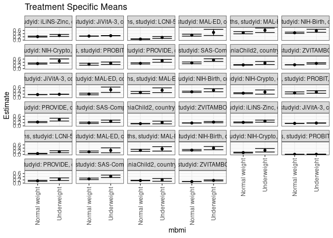

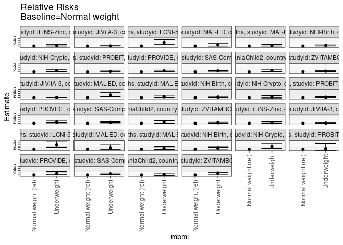

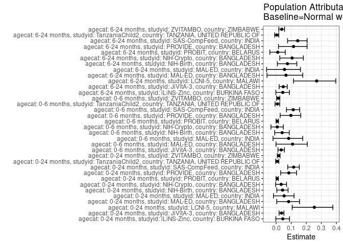

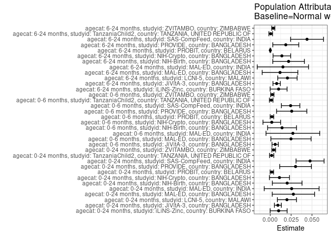

## Results Table

### Parameter: TSM

| agecat | studyid | country | intervention_level | baseline_level | estimate | ci_lower | ci_upper |
| --- | --- | --- | --- | --- | --- | --- | --- |
| 0-24 months | iLiNS-Zinc | BURKINA FASO | Normal weight | NA | 0.2178010 | 0.1881221 | 0.2474800 |
| 0-24 months | iLiNS-Zinc | BURKINA FASO | Underweight | NA | 0.2881117 | 0.2261854 | 0.3500379 |
| 0-24 months | JiVitA-3 | BANGLADESH | Normal weight | NA | 0.2488875 | 0.2412389 | 0.2565361 |
| 0-24 months | JiVitA-3 | BANGLADESH | Underweight | NA | 0.2726303 | 0.2631955 | 0.2820651 |
| 0-24 months | LCNI-5 | MALAWI | Normal weight | NA | 0.0588588 | 0.0413128 | 0.0764048 |
| 0-24 months | LCNI-5 | MALAWI | Underweight | NA | 0.1616966 | 0.1018737 | 0.2215194 |
| 0-24 months | MAL-ED | BANGLADESH | Normal weight | NA | 0.3069290 | 0.2462239 | 0.3676341 |
| 0-24 months | MAL-ED | BANGLADESH | Underweight | NA | 0.4775695 | 0.2851193 | 0.6700197 |
| 0-24 months | MAL-ED | INDIA | Normal weight | NA | 0.4578397 | 0.3874160 | 0.5282634 |
| 0-24 months | MAL-ED | INDIA | Underweight | NA | 0.6138412 | 0.4730525 | 0.7546300 |
| 0-24 months | NIH-Birth | BANGLADESH | Normal weight | NA | 0.4572876 | 0.4143561 | 0.5002191 |
| 0-24 months | NIH-Birth | BANGLADESH | Underweight | NA | 0.5800691 | 0.4844891 | 0.6756492 |
| 0-24 months | NIH-Crypto | BANGLADESH | Normal weight | NA | 0.3187909 | 0.2835936 | 0.3539882 |
| 0-24 months | NIH-Crypto | BANGLADESH | Underweight | NA | 0.4803598 | 0.3487077 | 0.6120119 |
| 0-24 months | PROBIT | BELARUS | Normal weight | NA | 0.2787784 | 0.2165305 | 0.3410263 |
| 0-24 months | PROBIT | BELARUS | Underweight | NA | 0.3378020 | 0.2610348 | 0.4145692 |
| 0-24 months | PROVIDE | BANGLADESH | Normal weight | NA | 0.3299192 | 0.2902964 | 0.3695420 |
| 0-24 months | PROVIDE | BANGLADESH | Underweight | NA | 0.4921550 | 0.4008519 | 0.5834582 |
| 0-24 months | SAS-CompFeed | INDIA | Normal weight | NA | 0.3631256 | 0.3072146 | 0.4190367 |
| 0-24 months | SAS-CompFeed | INDIA | Underweight | NA | 0.5362040 | 0.4523152 | 0.6200928 |
| 0-24 months | TanzaniaChild2 | TANZANIA, UNITED REPUBLIC OF | Normal weight | NA | 0.2353762 | 0.2178861 | 0.2528663 |
| 0-24 months | TanzaniaChild2 | TANZANIA, UNITED REPUBLIC OF | Underweight | NA | 0.3518346 | 0.2536381 | 0.4500312 |
| 0-24 months | ZVITAMBO | ZIMBABWE | Normal weight | NA | 0.2429380 | 0.2342053 | 0.2516706 |
| 0-24 months | ZVITAMBO | ZIMBABWE | Underweight | NA | 0.3281594 | 0.2855414 | 0.3707773 |
| 0-6 months | JiVitA-3 | BANGLADESH | Normal weight | NA | 0.1703054 | 0.1633914 | 0.1772194 |
| 0-6 months | JiVitA-3 | BANGLADESH | Underweight | NA | 0.1856782 | 0.1775618 | 0.1937946 |
| 0-6 months | MAL-ED | BANGLADESH | Normal weight | NA | 0.2034863 | 0.1504956 | 0.2564769 |
| 0-6 months | MAL-ED | BANGLADESH | Underweight | NA | 0.4708952 | 0.3013580 | 0.6404323 |
| 0-6 months | MAL-ED | INDIA | Normal weight | NA | 0.2993444 | 0.2345607 | 0.3641281 |
| 0-6 months | MAL-ED | INDIA | Underweight | NA | 0.4400641 | 0.2941443 | 0.5859838 |
| 0-6 months | NIH-Birth | BANGLADESH | Normal weight | NA | 0.3427677 | 0.3018758 | 0.3836595 |
| 0-6 months | NIH-Birth | BANGLADESH | Underweight | NA | 0.4401728 | 0.3434652 | 0.5368804 |
| 0-6 months | NIH-Crypto | BANGLADESH | Normal weight | NA | 0.2551061 | 0.2222832 | 0.2879291 |
| 0-6 months | NIH-Crypto | BANGLADESH | Underweight | NA | 0.3268944 | 0.1966738 | 0.4571150 |
| 0-6 months | PROBIT | BELARUS | Normal weight | NA | 0.2729493 | 0.2104902 | 0.3354085 |
| 0-6 months | PROBIT | BELARUS | Underweight | NA | 0.3291558 | 0.2495863 | 0.4087254 |
| 0-6 months | PROVIDE | BANGLADESH | Normal weight | NA | 0.2373776 | 0.2015021 | 0.2732531 |
| 0-6 months | PROVIDE | BANGLADESH | Underweight | NA | 0.3907932 | 0.3025564 | 0.4790299 |
| 0-6 months | SAS-CompFeed | INDIA | Normal weight | NA | 0.1910618 | 0.1494389 | 0.2326847 |
| 0-6 months | SAS-CompFeed | INDIA | Underweight | NA | 0.2880964 | 0.2171024 | 0.3590904 |
| 0-6 months | TanzaniaChild2 | TANZANIA, UNITED REPUBLIC OF | Normal weight | NA | 0.1391417 | 0.1248886 | 0.1533949 |
| 0-6 months | TanzaniaChild2 | TANZANIA, UNITED REPUBLIC OF | Underweight | NA | 0.2105263 | 0.1264891 | 0.2945635 |
| 0-6 months | ZVITAMBO | ZIMBABWE | Normal weight | NA | 0.1800638 | 0.1722273 | 0.1879002 |
| 0-6 months | ZVITAMBO | ZIMBABWE | Underweight | NA | 0.2347217 | 0.1962491 | 0.2731942 |
| 6-24 months | iLiNS-Zinc | BURKINA FASO | Normal weight | NA | 0.2178394 | 0.1882782 | 0.2474007 |
| 6-24 months | iLiNS-Zinc | BURKINA FASO | Underweight | NA | 0.2950062 | 0.2305888 | 0.3594236 |
| 6-24 months | JiVitA-3 | BANGLADESH | Normal weight | NA | 0.1560627 | 0.1487624 | 0.1633630 |
| 6-24 months | JiVitA-3 | BANGLADESH | Underweight | NA | 0.1759694 | 0.1662991 | 0.1856397 |
| 6-24 months | LCNI-5 | MALAWI | Normal weight | NA | 0.0559637 | 0.0386698 | 0.0732576 |
| 6-24 months | LCNI-5 | MALAWI | Underweight | NA | 0.1717243 | 0.1079321 | 0.2355166 |
| 6-24 months | MAL-ED | BANGLADESH | Normal weight | NA | 0.1674641 | 0.1167366 | 0.2181917 |
| 6-24 months | MAL-ED | BANGLADESH | Underweight | NA | 0.2580645 | 0.1037094 | 0.4124197 |
| 6-24 months | MAL-ED | INDIA | Normal weight | NA | 0.2583224 | 0.1951937 | 0.3214510 |
| 6-24 months | MAL-ED | INDIA | Underweight | NA | 0.3530682 | 0.2137255 | 0.4924109 |
| 6-24 months | NIH-Birth | BANGLADESH | Normal weight | NA | 0.2713770 | 0.2302493 | 0.3125047 |
| 6-24 months | NIH-Birth | BANGLADESH | Underweight | NA | 0.3973538 | 0.2961556 | 0.4985520 |
| 6-24 months | NIH-Crypto | BANGLADESH | Normal weight | NA | 0.1175904 | 0.0930471 | 0.1421336 |
| 6-24 months | NIH-Crypto | BANGLADESH | Underweight | NA | 0.2644501 | 0.1544174 | 0.3744828 |
| 6-24 months | PROBIT | BELARUS | Normal weight | NA | 0.0089414 | 0.0044666 | 0.0134163 |
| 6-24 months | PROBIT | BELARUS | Underweight | NA | 0.0114723 | -0.0012562 | 0.0242007 |
| 6-24 months | PROVIDE | BANGLADESH | Normal weight | NA | 0.1426353 | 0.1122238 | 0.1730468 |
| 6-24 months | PROVIDE | BANGLADESH | Underweight | NA | 0.2420604 | 0.1587186 | 0.3254022 |
| 6-24 months | SAS-CompFeed | INDIA | Normal weight | NA | 0.2636975 | 0.2139379 | 0.3134572 |
| 6-24 months | SAS-CompFeed | INDIA | Underweight | NA | 0.4227097 | 0.3456562 | 0.4997632 |
| 6-24 months | TanzaniaChild2 | TANZANIA, UNITED REPUBLIC OF | Normal weight | NA | 0.1606591 | 0.1441588 | 0.1771595 |
| 6-24 months | TanzaniaChild2 | TANZANIA, UNITED REPUBLIC OF | Underweight | NA | 0.2000000 | 0.1128772 | 0.2871228 |
| 6-24 months | ZVITAMBO | ZIMBABWE | Normal weight | NA | 0.0950038 | 0.0886304 | 0.1013771 |
| 6-24 months | ZVITAMBO | ZIMBABWE | Underweight | NA | 0.1664112 | 0.1316495 | 0.2011728 |

### Parameter: E(Y)

| agecat | studyid | country | intervention_level | baseline_level | estimate | ci_lower | ci_upper |
| --- | --- | --- | --- | --- | --- | --- | --- |
| 0-24 months | iLiNS-Zinc | BURKINA FASO | NA | NA | 0.2278520 | 0.2008644 | 0.2548397 |
| 0-24 months | JiVitA-3 | BANGLADESH | NA | NA | 0.2580489 | 0.2515797 | 0.2645181 |
| 0-24 months | LCNI-5 | MALAWI | NA | NA | 0.0788530 | 0.0605839 | 0.0971222 |
| 0-24 months | MAL-ED | BANGLADESH | NA | NA | 0.3346457 | 0.2765014 | 0.3927899 |
| 0-24 months | MAL-ED | INDIA | NA | NA | 0.4834711 | 0.4203794 | 0.5465628 |
| 0-24 months | NIH-Birth | BANGLADESH | NA | NA | 0.4775641 | 0.4383415 | 0.5167867 |
| 0-24 months | NIH-Crypto | BANGLADESH | NA | NA | 0.3298013 | 0.2962438 | 0.3633589 |
| 0-24 months | PROBIT | BELARUS | NA | NA | 0.2807401 | 0.2185990 | 0.3428812 |
| 0-24 months | PROVIDE | BANGLADESH | NA | NA | 0.3602392 | 0.3238339 | 0.3966444 |
| 0-24 months | SAS-CompFeed | INDIA | NA | NA | 0.4107914 | 0.3512139 | 0.4703688 |
| 0-24 months | TanzaniaChild2 | TANZANIA, UNITED REPUBLIC OF | NA | NA | 0.2371002 | 0.2198828 | 0.2543177 |
| 0-24 months | ZVITAMBO | ZIMBABWE | NA | NA | 0.2471165 | 0.2385749 | 0.2556580 |
| 0-6 months | JiVitA-3 | BANGLADESH | NA | NA | 0.1762220 | 0.1706009 | 0.1818431 |
| 0-6 months | MAL-ED | BANGLADESH | NA | NA | 0.2283465 | 0.1766220 | 0.2800709 |
| 0-6 months | MAL-ED | INDIA | NA | NA | 0.3264463 | 0.2672449 | 0.3856476 |
| 0-6 months | NIH-Birth | BANGLADESH | NA | NA | 0.3569132 | 0.3192325 | 0.3945938 |
| 0-6 months | NIH-Crypto | BANGLADESH | NA | NA | 0.2569536 | 0.2257649 | 0.2881424 |
| 0-6 months | PROBIT | BELARUS | NA | NA | 0.2749854 | 0.2126043 | 0.3373666 |
| 0-6 months | PROVIDE | BANGLADESH | NA | NA | 0.2630792 | 0.2296894 | 0.2964690 |
| 0-6 months | SAS-CompFeed | INDIA | NA | NA | 0.2154736 | 0.1691818 | 0.2617655 |
| 0-6 months | TanzaniaChild2 | TANZANIA, UNITED REPUBLIC OF | NA | NA | 0.1402985 | 0.1262390 | 0.1543580 |
| 0-6 months | ZVITAMBO | ZIMBABWE | NA | NA | 0.1825820 | 0.1749172 | 0.1902467 |
| 6-24 months | iLiNS-Zinc | BURKINA FASO | NA | NA | 0.2278520 | 0.2008644 | 0.2548397 |
| 6-24 months | JiVitA-3 | BANGLADESH | NA | NA | 0.1637481 | 0.1576337 | 0.1698625 |
| 6-24 months | LCNI-5 | MALAWI | NA | NA | 0.0765492 | 0.0583736 | 0.0947248 |
| 6-24 months | MAL-ED | BANGLADESH | NA | NA | 0.1791667 | 0.1305478 | 0.2277856 |
| 6-24 months | MAL-ED | INDIA | NA | NA | 0.2735043 | 0.2162683 | 0.3307402 |
| 6-24 months | NIH-Birth | BANGLADESH | NA | NA | 0.2933579 | 0.2549918 | 0.3317241 |
| 6-24 months | NIH-Crypto | BANGLADESH | NA | NA | 0.1315068 | 0.1069744 | 0.1560393 |
| 6-24 months | PROBIT | BELARUS | NA | NA | 0.0090379 | 0.0045686 | 0.0135072 |
| 6-24 months | PROVIDE | BANGLADESH | NA | NA | 0.1612378 | 0.1321259 | 0.1903497 |
| 6-24 months | SAS-CompFeed | INDIA | NA | NA | 0.3077525 | 0.2591695 | 0.3563356 |
| 6-24 months | TanzaniaChild2 | TANZANIA, UNITED REPUBLIC OF | NA | NA | 0.1612576 | 0.1450216 | 0.1774936 |
| 6-24 months | ZVITAMBO | ZIMBABWE | NA | NA | 0.0986391 | 0.0923357 | 0.1049424 |

### Parameter: RR

| agecat | studyid | country | intervention_level | baseline_level | estimate | ci_lower | ci_upper |
| --- | --- | --- | --- | --- | --- | --- | --- |
| 0-24 months | iLiNS-Zinc | BURKINA FASO | Normal weight | Normal weight | 1.000000 | 1.0000000 | 1.000000 |
| 0-24 months | iLiNS-Zinc | BURKINA FASO | Underweight | Normal weight | 1.322820 | 1.0192460 | 1.716812 |
| 0-24 months | JiVitA-3 | BANGLADESH | Normal weight | Normal weight | 1.000000 | 1.0000000 | 1.000000 |
| 0-24 months | JiVitA-3 | BANGLADESH | Underweight | Normal weight | 1.095396 | 1.0509026 | 1.141772 |
| 0-24 months | LCNI-5 | MALAWI | Normal weight | Normal weight | 1.000000 | 1.0000000 | 1.000000 |
| 0-24 months | LCNI-5 | MALAWI | Underweight | Normal weight | 2.747195 | 1.7099645 | 4.413588 |
| 0-24 months | MAL-ED | BANGLADESH | Normal weight | Normal weight | 1.000000 | 1.0000000 | 1.000000 |
| 0-24 months | MAL-ED | BANGLADESH | Underweight | Normal weight | 1.555961 | 0.9907706 | 2.443567 |
| 0-24 months | MAL-ED | INDIA | Normal weight | Normal weight | 1.000000 | 1.0000000 | 1.000000 |
| 0-24 months | MAL-ED | INDIA | Underweight | Normal weight | 1.340734 | 1.0153150 | 1.770453 |
| 0-24 months | NIH-Birth | BANGLADESH | Normal weight | Normal weight | 1.000000 | 1.0000000 | 1.000000 |
| 0-24 months | NIH-Birth | BANGLADESH | Underweight | Normal weight | 1.268500 | 1.0492966 | 1.533495 |
| 0-24 months | NIH-Crypto | BANGLADESH | Normal weight | Normal weight | 1.000000 | 1.0000000 | 1.000000 |
| 0-24 months | NIH-Crypto | BANGLADESH | Underweight | Normal weight | 1.506818 | 1.1214223 | 2.024661 |
| 0-24 months | PROBIT | BELARUS | Normal weight | Normal weight | 1.000000 | 1.0000000 | 1.000000 |
| 0-24 months | PROBIT | BELARUS | Underweight | Normal weight | 1.211722 | 1.0334112 | 1.420800 |
| 0-24 months | PROVIDE | BANGLADESH | Normal weight | Normal weight | 1.000000 | 1.0000000 | 1.000000 |
| 0-24 months | PROVIDE | BANGLADESH | Underweight | Normal weight | 1.491744 | 1.1957326 | 1.861035 |
| 0-24 months | SAS-CompFeed | INDIA | Normal weight | Normal weight | 1.000000 | 1.0000000 | 1.000000 |
| 0-24 months | SAS-CompFeed | INDIA | Underweight | Normal weight | 1.476635 | 1.2941174 | 1.684894 |
| 0-24 months | TanzaniaChild2 | TANZANIA, UNITED REPUBLIC OF | Normal weight | Normal weight | 1.000000 | 1.0000000 | 1.000000 |
| 0-24 months | TanzaniaChild2 | TANZANIA, UNITED REPUBLIC OF | Underweight | Normal weight | 1.494776 | 1.1198269 | 1.995267 |
| 0-24 months | ZVITAMBO | ZIMBABWE | Normal weight | Normal weight | 1.000000 | 1.0000000 | 1.000000 |
| 0-24 months | ZVITAMBO | ZIMBABWE | Underweight | Normal weight | 1.350795 | 1.1804930 | 1.545665 |
| 0-6 months | JiVitA-3 | BANGLADESH | Normal weight | Normal weight | 1.000000 | 1.0000000 | 1.000000 |
| 0-6 months | JiVitA-3 | BANGLADESH | Underweight | Normal weight | 1.090266 | 1.0318871 | 1.151948 |
| 0-6 months | MAL-ED | BANGLADESH | Normal weight | Normal weight | 1.000000 | 1.0000000 | 1.000000 |
| 0-6 months | MAL-ED | BANGLADESH | Underweight | Normal weight | 2.314137 | 1.4813227 | 3.615169 |
| 0-6 months | MAL-ED | INDIA | Normal weight | Normal weight | 1.000000 | 1.0000000 | 1.000000 |
| 0-6 months | MAL-ED | INDIA | Underweight | Normal weight | 1.470093 | 0.9877867 | 2.187894 |
| 0-6 months | NIH-Birth | BANGLADESH | Normal weight | Normal weight | 1.000000 | 1.0000000 | 1.000000 |
| 0-6 months | NIH-Birth | BANGLADESH | Underweight | Normal weight | 1.284172 | 1.0007881 | 1.647800 |
| 0-6 months | NIH-Crypto | BANGLADESH | Normal weight | Normal weight | 1.000000 | 1.0000000 | 1.000000 |
| 0-6 months | NIH-Crypto | BANGLADESH | Underweight | Normal weight | 1.281405 | 0.8427622 | 1.948355 |
| 0-6 months | PROBIT | BELARUS | Normal weight | Normal weight | 1.000000 | 1.0000000 | 1.000000 |
| 0-6 months | PROBIT | BELARUS | Underweight | Normal weight | 1.205923 | 1.0187899 | 1.427428 |
| 0-6 months | PROVIDE | BANGLADESH | Normal weight | Normal weight | 1.000000 | 1.0000000 | 1.000000 |
| 0-6 months | PROVIDE | BANGLADESH | Underweight | Normal weight | 1.646293 | 1.2544277 | 2.160573 |
| 0-6 months | SAS-CompFeed | INDIA | Normal weight | Normal weight | 1.000000 | 1.0000000 | 1.000000 |
| 0-6 months | SAS-CompFeed | INDIA | Underweight | Normal weight | 1.507870 | 1.2776398 | 1.779588 |
| 0-6 months | TanzaniaChild2 | TANZANIA, UNITED REPUBLIC OF | Normal weight | Normal weight | 1.000000 | 1.0000000 | 1.000000 |
| 0-6 months | TanzaniaChild2 | TANZANIA, UNITED REPUBLIC OF | Underweight | Normal weight | 1.513035 | 1.0020087 | 2.284685 |
| 0-6 months | ZVITAMBO | ZIMBABWE | Normal weight | Normal weight | 1.000000 | 1.0000000 | 1.000000 |
| 0-6 months | ZVITAMBO | ZIMBABWE | Underweight | Normal weight | 1.303547 | 1.1001846 | 1.544500 |
| 6-24 months | iLiNS-Zinc | BURKINA FASO | Normal weight | Normal weight | 1.000000 | 1.0000000 | 1.000000 |
| 6-24 months | iLiNS-Zinc | BURKINA FASO | Underweight | Normal weight | 1.354237 | 1.0407680 | 1.762120 |
| 6-24 months | JiVitA-3 | BANGLADESH | Normal weight | Normal weight | 1.000000 | 1.0000000 | 1.000000 |
| 6-24 months | JiVitA-3 | BANGLADESH | Underweight | Normal weight | 1.127556 | 1.0532019 | 1.207159 |
| 6-24 months | LCNI-5 | MALAWI | Normal weight | Normal weight | 1.000000 | 1.0000000 | 1.000000 |
| 6-24 months | LCNI-5 | MALAWI | Underweight | Normal weight | 3.068493 | 1.8943048 | 4.970505 |
| 6-24 months | MAL-ED | BANGLADESH | Normal weight | Normal weight | 1.000000 | 1.0000000 | 1.000000 |
| 6-24 months | MAL-ED | BANGLADESH | Underweight | Normal weight | 1.541014 | 0.7881894 | 3.012884 |
| 6-24 months | MAL-ED | INDIA | Normal weight | Normal weight | 1.000000 | 1.0000000 | 1.000000 |
| 6-24 months | MAL-ED | INDIA | Underweight | Normal weight | 1.366774 | 0.8583700 | 2.176299 |
| 6-24 months | NIH-Birth | BANGLADESH | Normal weight | Normal weight | 1.000000 | 1.0000000 | 1.000000 |
| 6-24 months | NIH-Birth | BANGLADESH | Underweight | Normal weight | 1.464213 | 1.0885851 | 1.969456 |
| 6-24 months | NIH-Crypto | BANGLADESH | Normal weight | Normal weight | 1.000000 | 1.0000000 | 1.000000 |
| 6-24 months | NIH-Crypto | BANGLADESH | Underweight | Normal weight | 2.248910 | 1.4117280 | 3.582556 |
| 6-24 months | PROBIT | BELARUS | Normal weight | Normal weight | 1.000000 | 1.0000000 | 1.000000 |
| 6-24 months | PROBIT | BELARUS | Underweight | Normal weight | 1.283048 | 0.4377605 | 3.760530 |
| 6-24 months | PROVIDE | BANGLADESH | Normal weight | Normal weight | 1.000000 | 1.0000000 | 1.000000 |
| 6-24 months | PROVIDE | BANGLADESH | Underweight | Normal weight | 1.697058 | 1.1332129 | 2.541453 |
| 6-24 months | SAS-CompFeed | INDIA | Normal weight | Normal weight | 1.000000 | 1.0000000 | 1.000000 |
| 6-24 months | SAS-CompFeed | INDIA | Underweight | Normal weight | 1.603010 | 1.3019817 | 1.973638 |
| 6-24 months | TanzaniaChild2 | TANZANIA, UNITED REPUBLIC OF | Normal weight | Normal weight | 1.000000 | 1.0000000 | 1.000000 |
| 6-24 months | TanzaniaChild2 | TANZANIA, UNITED REPUBLIC OF | Underweight | Normal weight | 1.244872 | 0.7957064 | 1.947585 |
| 6-24 months | ZVITAMBO | ZIMBABWE | Normal weight | Normal weight | 1.000000 | 1.0000000 | 1.000000 |
| 6-24 months | ZVITAMBO | ZIMBABWE | Underweight | Normal weight | 1.751627 | 1.4065942 | 2.181295 |

### Parameter: PAR

| agecat | studyid | country | intervention_level | baseline_level | estimate | ci_lower | ci_upper |
| --- | --- | --- | --- | --- | --- | --- | --- |
| 0-24 months | iLiNS-Zinc | BURKINA FASO | Normal weight | NA | 0.0100510 | -0.0001108 | 0.0202128 |
| 0-24 months | JiVitA-3 | BANGLADESH | Normal weight | NA | 0.0091614 | 0.0050080 | 0.0133148 |
| 0-24 months | LCNI-5 | MALAWI | Normal weight | NA | 0.0199943 | 0.0085953 | 0.0313932 |
| 0-24 months | MAL-ED | BANGLADESH | Normal weight | NA | 0.0277167 | 0.0023430 | 0.0530903 |
| 0-24 months | MAL-ED | INDIA | Normal weight | NA | 0.0256314 | -0.0072028 | 0.0584656 |
| 0-24 months | NIH-Birth | BANGLADESH | Normal weight | NA | 0.0202765 | 0.0024630 | 0.0380901 |
| 0-24 months | NIH-Crypto | BANGLADESH | Normal weight | NA | 0.0110105 | -0.0009684 | 0.0229893 |
| 0-24 months | PROBIT | BELARUS | Normal weight | NA | 0.0019617 | -0.0001170 | 0.0040404 |
| 0-24 months | PROVIDE | BANGLADESH | Normal weight | NA | 0.0303200 | 0.0113076 | 0.0493323 |
| 0-24 months | SAS-CompFeed | INDIA | Normal weight | NA | 0.0476657 | 0.0308812 | 0.0644503 |
| 0-24 months | TanzaniaChild2 | TANZANIA, UNITED REPUBLIC OF | Normal weight | NA | 0.0017240 | -0.0008056 | 0.0042535 |
| 0-24 months | ZVITAMBO | ZIMBABWE | Normal weight | NA | 0.0041785 | 0.0019556 | 0.0064014 |
| 0-6 months | JiVitA-3 | BANGLADESH | Normal weight | NA | 0.0059166 | 0.0021606 | 0.0096726 |
| 0-6 months | MAL-ED | BANGLADESH | Normal weight | NA | 0.0248602 | 0.0008025 | 0.0489179 |
| 0-6 months | MAL-ED | INDIA | Normal weight | NA | 0.0271019 | -0.0050665 | 0.0592702 |
| 0-6 months | NIH-Birth | BANGLADESH | Normal weight | NA | 0.0141455 | -0.0031277 | 0.0314188 |
| 0-6 months | NIH-Crypto | BANGLADESH | Normal weight | NA | 0.0018475 | -0.0087201 | 0.0124151 |
| 0-6 months | PROBIT | BELARUS | Normal weight | NA | 0.0020361 | -0.0000835 | 0.0041557 |
| 0-6 months | PROVIDE | BANGLADESH | Normal weight | NA | 0.0257016 | 0.0075816 | 0.0438217 |
| 0-6 months | SAS-CompFeed | INDIA | Normal weight | NA | 0.0244118 | 0.0133678 | 0.0354558 |
| 0-6 months | TanzaniaChild2 | TANZANIA, UNITED REPUBLIC OF | Normal weight | NA | 0.0011568 | -0.0010052 | 0.0033187 |
| 0-6 months | ZVITAMBO | ZIMBABWE | Normal weight | NA | 0.0025182 | 0.0005389 | 0.0044974 |
| 6-24 months | iLiNS-Zinc | BURKINA FASO | Normal weight | NA | 0.0100126 | -0.0001047 | 0.0201299 |
| 6-24 months | JiVitA-3 | BANGLADESH | Normal weight | NA | 0.0076854 | 0.0032812 | 0.0120896 |
| 6-24 months | LCNI-5 | MALAWI | Normal weight | NA | 0.0205855 | 0.0089575 | 0.0322135 |
| 6-24 months | MAL-ED | BANGLADESH | Normal weight | NA | 0.0117026 | -0.0096347 | 0.0330398 |
| 6-24 months | MAL-ED | INDIA | Normal weight | NA | 0.0151819 | -0.0155319 | 0.0458957 |
| 6-24 months | NIH-Birth | BANGLADESH | Normal weight | NA | 0.0219809 | 0.0030166 | 0.0409453 |
| 6-24 months | NIH-Crypto | BANGLADESH | Normal weight | NA | 0.0139165 | 0.0033829 | 0.0244500 |
| 6-24 months | PROBIT | BELARUS | Normal weight | NA | 0.0000965 | -0.0003675 | 0.0005605 |
| 6-24 months | PROVIDE | BANGLADESH | Normal weight | NA | 0.0186025 | 0.0030433 | 0.0341617 |
| 6-24 months | SAS-CompFeed | INDIA | Normal weight | NA | 0.0440550 | 0.0243570 | 0.0637531 |
| 6-24 months | TanzaniaChild2 | TANZANIA, UNITED REPUBLIC OF | Normal weight | NA | 0.0005985 | -0.0016285 | 0.0028255 |
| 6-24 months | ZVITAMBO | ZIMBABWE | Normal weight | NA | 0.0036353 | 0.0017579 | 0.0055127 |

### Parameter: PAF

| agecat | studyid | country | intervention_level | baseline_level | estimate | ci_lower | ci_upper |
| --- | --- | --- | --- | --- | --- | --- | --- |
| 0-24 months | iLiNS-Zinc | BURKINA FASO | Normal weight | NA | 0.0441119 | -0.0023487 | 0.0884190 |
| 0-24 months | JiVitA-3 | BANGLADESH | Normal weight | NA | 0.0355025 | 0.0192572 | 0.0514787 |
| 0-24 months | LCNI-5 | MALAWI | Normal weight | NA | 0.2535635 | 0.1066145 | 0.3763416 |
| 0-24 months | MAL-ED | BANGLADESH | Normal weight | NA | 0.0828239 | 0.0040946 | 0.1553294 |
| 0-24 months | MAL-ED | INDIA | Normal weight | NA | 0.0530154 | -0.0175930 | 0.1187244 |
| 0-24 months | NIH-Birth | BANGLADESH | Normal weight | NA | 0.0424583 | 0.0042849 | 0.0791681 |
| 0-24 months | NIH-Crypto | BANGLADESH | Normal weight | NA | 0.0333851 | -0.0036573 | 0.0690604 |
| 0-24 months | PROBIT | BELARUS | Normal weight | NA | 0.0069876 | -0.0006582 | 0.0145751 |
| 0-24 months | PROVIDE | BANGLADESH | Normal weight | NA | 0.0841662 | 0.0298732 | 0.1354206 |
| 0-24 months | SAS-CompFeed | INDIA | Normal weight | NA | 0.1160340 | 0.0768798 | 0.1535274 |
| 0-24 months | TanzaniaChild2 | TANZANIA, UNITED REPUBLIC OF | Normal weight | NA | 0.0072711 | -0.0034870 | 0.0179139 |
| 0-24 months | ZVITAMBO | ZIMBABWE | Normal weight | NA | 0.0169090 | 0.0078787 | 0.0258570 |
| 0-6 months | JiVitA-3 | BANGLADESH | Normal weight | NA | 0.0335747 | 0.0119419 | 0.0547339 |
| 0-6 months | MAL-ED | BANGLADESH | Normal weight | NA | 0.1088705 | -0.0012274 | 0.2068618 |
| 0-6 months | MAL-ED | INDIA | Normal weight | NA | 0.0830209 | -0.0207819 | 0.1762681 |
| 0-6 months | NIH-Birth | BANGLADESH | Normal weight | NA | 0.0396330 | -0.0100380 | 0.0868612 |
| 0-6 months | NIH-Crypto | BANGLADESH | Normal weight | NA | 0.0071900 | -0.0348002 | 0.0474763 |
| 0-6 months | PROBIT | BELARUS | Normal weight | NA | 0.0074043 | -0.0005488 | 0.0152943 |
| 0-6 months | PROVIDE | BANGLADESH | Normal weight | NA | 0.0976954 | 0.0266458 | 0.1635588 |
| 0-6 months | SAS-CompFeed | INDIA | Normal weight | NA | 0.1132936 | 0.0683724 | 0.1560488 |
| 0-6 months | TanzaniaChild2 | TANZANIA, UNITED REPUBLIC OF | Normal weight | NA | 0.0082450 | -0.0073186 | 0.0235682 |
| 0-6 months | ZVITAMBO | ZIMBABWE | Normal weight | NA | 0.0137921 | 0.0029005 | 0.0245647 |
| 6-24 months | iLiNS-Zinc | BURKINA FASO | Normal weight | NA | 0.0439435 | -0.0022518 | 0.0880096 |
| 6-24 months | JiVitA-3 | BANGLADESH | Normal weight | NA | 0.0469343 | 0.0197129 | 0.0733998 |
| 6-24 months | LCNI-5 | MALAWI | Normal weight | NA | 0.2689183 | 0.1150010 | 0.3960666 |
| 6-24 months | MAL-ED | BANGLADESH | Normal weight | NA | 0.0653166 | -0.0608054 | 0.1764436 |
| 6-24 months | MAL-ED | INDIA | Normal weight | NA | 0.0555089 | -0.0635425 | 0.1612338 |
| 6-24 months | NIH-Birth | BANGLADESH | Normal weight | NA | 0.0749287 | 0.0081864 | 0.1371798 |
| 6-24 months | NIH-Crypto | BANGLADESH | Normal weight | NA | 0.1058233 | 0.0240000 | 0.1807869 |
| 6-24 months | PROBIT | BELARUS | Normal weight | NA | 0.0106745 | -0.0420841 | 0.0607620 |
| 6-24 months | PROVIDE | BANGLADESH | Normal weight | NA | 0.1153731 | 0.0151440 | 0.2054018 |
| 6-24 months | SAS-CompFeed | INDIA | Normal weight | NA | 0.1431508 | 0.0758637 | 0.2055386 |
| 6-24 months | TanzaniaChild2 | TANZANIA, UNITED REPUBLIC OF | Normal weight | NA | 0.0037114 | -0.0102192 | 0.0174499 |
| 6-24 months | ZVITAMBO | ZIMBABWE | Normal weight | NA | 0.0368544 | 0.0177514 | 0.0555860 |